# Modern Data Mining - HW 4

Sung Cho

Etienne Lee

Leo Li

Due: Sunday, April 5, 2026, 11:59 PM

# Overview

For prediction tasks, nonlinear models or model-free approaches can often outperform traditional statistical methods by capturing complex patterns in data. Neural networks provide a powerful framework for such predictions, as they can learn intricate relationships without explicitly programmed rules. Their ability to recognize nonlinear dependencies makes them particularly useful for tasks where traditional models struggle. Neural networks are widely applied in image and speech recognition, natural language processing (NLP), time series forecasting, and many other domains.

While neural networks have been studied for decades, their recent surge in popularity is driven by several factors. First, the explosion of available data enables more robust training, improving model accuracy. Second, advancements in hardware technology, such as GPUs and TPUs, have significantly reduced the cost and time required for training large-scale models. Third, the introduction of specialized architectures, such as convolutional neural networks (CNNs) for image tasks and recurrent neural networks (RNNs) for sequential data, has led to breakthroughs in various domains. Finally, the emergence of deep learning, which leverages deep neural networks with many layers, has enabled state-of-the-art performance across a wide range of applications.

A natural extension of these deep learning models is the rise of large language models (LLMs), such as those based on BERT (Bidirectional Encoder Representations from Transformers). Unlike traditional NLP models, BERT embeddings capture contextual meaning by processing text bidirectionally, allowing for more nuanced understanding and improved accuracy in language-related tasks. These models have revolutionized NLP, powering applications such as machine translation, sentiment analysis, and question answering. By combining neural networks, bag-of-words models, and LLMs, we can tackle diverse predictive problems across structured and unstructured data.

## Objectives

- Understand text mining and bag-of-words models
  - Be able to preprocess text data and construct a document-term matrix
  - Understand what the DTM records
  - Be able to interpret sparsity, coefficients, and word clouds
- Understand prediction tasks with different outcomes
  - Distinguish between binary classification and five-class classification
  - Compare models under the same prediction task
- Understand a basic NN
  - Be able to write an architecture (a model)
  - Understand the roles of
    - Hidden layers
    - Neurons
    - Relu activation function
    - Softmax output
  - Be able to run keras to train and use a NN
- Start the LLM models
  - Sentiment pipeline
  - Embeddings
  - Fine-tuning as an advanced extension
- R functions/Packages
  - `keras3`, `glmnet`, `tm`, `jsonlite`
  - `transformers` through `reticulate`
- Json data format
- Bert transformers from Hugging Face
- Model evaluation
  - Accuracy
  - Misclassification error
  - Confusion matrix
  - Error analysis
- Reproducible reporting
  - Organize results clearly
  - Write concise interpretations tied to plots and model outputs

Data needed:

- `yelp_review_20k.json`
- `yelp_review_1200.json`

# Problem 0: Lectures

Please study the lecture materials and make sure you can run and compile the main examples from class.

- text mining
- deep learning
- LLM

# Problem 1: Yelp challenge 2019

**Note:** This problem is rather involved. It covers essentially all the main materials we have done so far in this semester. The goal is to connect the topics from text mining, neural networks, and LLMs into a meaningful case study. You should keep your work organized and reproducible. It could be thought as a guideline for your final project if you want when appropriate.

Yelp has made their data available to the public and launched the Yelp challenge. [More information](https://www.yelp.com/dataset/). For this case study, we downloaded the [data](https://www.yelp.com/dataset/download) and took a 20k subset from **review.json**. This homework uses a smaller working subset so that you can focus on modeling decisions and interpretation.

The file is stored in newline-delimited JSON (ndjson) format. Each line is one JSON object.

```json
{
  "key1": "value1",
  "key2": "value2"
}
{
  "key1": "value1",
  "key2": "value2"
}
```

The traditional JSON format is instead wrapped in square brackets.

```json
[{
  "key1": "value1",
  "key2": "value2"
},
{
  "key1": "value1",
  "key2": "value2"
}]
```

**Data needed:** yelp_review_20k.json available in Canvas.

**yelp_review_20k.json** contains full review text data including the user_id that wrote the review and the business_id the review is written for. Here’s an example of one review.

```json
{
    // string, 22 character unique review id
    "review_id": "zdSx_SD6obEhz9VrW9uAWA",

    // string, 22 character unique user id, maps to the user in user.json
    "user_id": "Ha3iJu77CxlrFm-vQRs_8g",

    // string, 22 character business id, maps to business in business.json
    "business_id": "tnhfDv5Il8EaGSXZGiuQGg",

    // integer, star rating
    "stars": 4,

    // string, date formatted YYYY-MM-DD
    "date": "2016-03-09",

    // string, the review itself
    "text": "Great place to hang out after work: the prices are decent, and the ambience is fun. It's a bit loud, but very lively. The staff is friendly, and the food is good. They have a good selection of drinks.",

    // integer, number of useful votes received
    "useful": 0,

    // integer, number of funny votes received
    "funny": 0,

    // integer, number of cool votes received
    "cool": 0
}
```

## Goal of the study

The goals are:

1. Identify important words associated with positive and negative ratings.
2. Predict ratings using multiple methods.
3. Compare two different text representations for prediction
4. Analyze not only which model performs best, but also where models make mistakes.

# Part 1: Data and EDA

## 1.1 Load the Yelp data

Use `stream_in()` in the `jsonlite` package to load the full `yelp_review_20k.json` file as a data frame. Use the full 20,000 reviews for the EDA and preprocessing summaries in Part 1.

```r
library(jsonlite)

yelp_20k <- stream_in(file("yelp_review_20k.json"))
```

```
## opening file input connection.
```

```
##  Found 500 records... Found 1000 records... Found 1500 records... Found 2000 records... Found 2500 records... Found 3000 records... Found 3500 records... Found 4000 records... Found 4500 records... Found 5000 records... Found 5500 records... Found 6000 records... Found 6500 records... Found 7000 …
```

```
## closing file input connection.
```

## 1.2 Basic data checks

Answer the following questions using the full 20,000 reviews.

### (a) Time period

What is the time period covered by these reviews? Report the earliest and latest review dates.

```r
as.Date(min(yelp_20k$date))
```

```
## [1] "2004-10-19"
```

```r
as.Date(max(yelp_20k$date))
```

```
## [1] "2018-10-04"
```

### (b) Rating distribution

Create a table of the number of reviews in each of the five rating categories for the full 20,000-review file.

```r
rating_table <- as.data.frame(table(yelp_20k$stars))
colnames(rating_table) <- c("stars", "count")
rating_table
```

```
##   stars count
## 1     1  2932
## 2     2  1530
## 3     3  2245
## 4     4  4356
## 5     5  8936
```

### (c) Ratings by month and weekday

Investigate whether ratings are related to month of the year or day of the week using EDA only on the full 20,000 reviews.

Your answer must include:

- one plot related to month,
- one plot related to weekday,
- and a short interpretation of at most 5 sentences.

Possible choices include counts by month/weekday, average rating by month/weekday, or stacked proportions by month/weekday.

```r
library(jsonlite)
library(dplyr)
library(ggplot2)
library(lubridate)
yelp_20k <- stream_in(file("yelp_review_20k.json"))
```

```
## opening file input connection.
```

```
##  Found 500 records... Found 1000 records... Found 1500 records... Found 2000 records... Found 2500 records... Found 3000 records... Found 3500 records... Found 4000 records... Found 4500 records... Found 5000 records... Found 5500 records... Found 6000 records... Found 6500 records... Found 7000 …
```

```
## closing file input connection.
```

[figure not shown]

```r
yelp_20k$date <- ymd_hms(yelp_20k$date)

yelp_20k <- yelp_20k %>%
  mutate(
    month = factor(month(date, label = TRUE, abbr = TRUE), levels = month.abb),
    weekday = factor(wday(date, label = TRUE, abbr = TRUE),
                     levels = c("Mon","Tue","Wed","Thu","Fri","Sat","Sun"))
  )

# Plot 1: average rating by month
yelp_20k %>%
  group_by(month) %>%
  summarise(avg_rating = mean(stars)) %>%
  ggplot(aes(x = month, y = avg_rating, group = 1)) +
  geom_line() +
  geom_point() +
  labs(title = "Average Yelp Rating by Month",
       x = "Month", y = "Average Rating") +
  theme_minimal()
```

[figure not shown]

```r
# Plot 2: average rating by weekday
yelp_20k %>%
  group_by(weekday) %>%
  summarise(avg_rating = mean(stars)) %>%
  ggplot(aes(x = weekday, y = avg_rating, group = 1)) +
  geom_line() +
  geom_point() +
  labs(title = "Average Yelp Rating by Weekday",
       x = "Weekday", y = "Average Rating") +
  theme_minimal()
```

Average ratings vary only a little across both month and weekday, so there is no strong seasonal or weekly pattern. By month, ratings are highest in about October and lowest in December. By weekday, ratings are highest around Wednesday to Friday and lowest on Sunday. Overall, the variation is small, suggesting that month and weekday have only a modest relationship with rating.

### (d) Short EDA summary

Summarize your key EDA findings in 3 to 5 sentences. Avoid making causal claims at this stage. Maintain a descriptive discussion, focusing on your observations in this exploratory phase.

The 20,000 Yelp reviews span from October 19, 2004 to October 4, 2018, covering about 14 years of review activity. The rating distribution is skewed positive, with 5-star reviews by far the most common category, followed by 4-star reviews, while 1-star and 2-star reviews are less frequent. The month and weekday plots suggest only modest variation in average ratings over time, with slightly lower averages in December and Sunday and slightly higher averages around October and midweek. Overall, the exploratory patterns suggest that most reviews are favorable and that calendar timing is only weakly related to average rating.

### (e) Text preprocessing summaries on the full data

Using the full 20,000 reviews, create the text object, corpus, and document-term matrix summary information.

Your answer must report at least:

- the number of documents in the corpus,
- the vocabulary size before sparsity filtering,
- the dimensions of the full DTM,
- and the sparsity of the full DTM.

You can also visualize this by creating a simple bar chart comparing the number of zero versus nonzero entries is sufficient.

```r
library(jsonlite)
library(tm)
```

```r
library(ggplot2)

yelp_20k <- jsonlite::stream_in(file("yelp_review_20k.json"), verbose = FALSE)

# text object
text_all <- yelp_20k$text

# corpus
corp_all <- VCorpus(VectorSource(text_all))

# preprocessing
corp_all <- tm_map(corp_all, content_transformer(tolower))
corp_all <- tm_map(corp_all, removePunctuation)
corp_all <- tm_map(corp_all, removeNumbers)
corp_all <- tm_map(corp_all, removeWords, stopwords("en"))
corp_all <- tm_map(corp_all, stripWhitespace)

# full DTM
dtm_all <- DocumentTermMatrix(corp_all)

# required summaries
num_docs <- length(corp_all)
vocab_size <- ncol(dtm_all)
dim(dtm_all)
```

```
## [1] 19999 42764
```

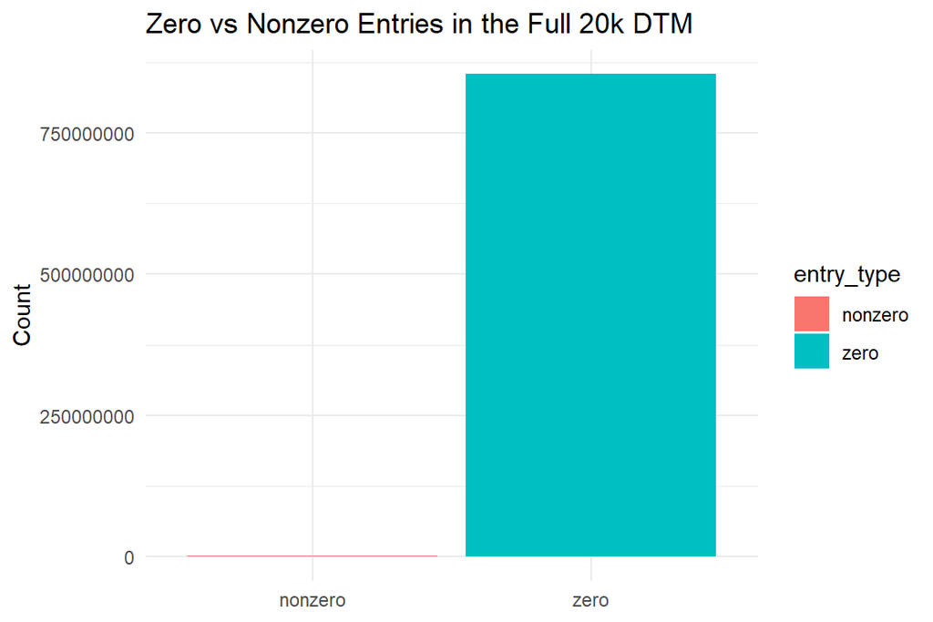

```r
# hint section
options(scipen = 999)
ncell_all <- nrow(dtm_all) * ncol(dtm_all)
nzero_all <- length(dtm_all$v)
sparsity_plot_data <- data.frame(
  entry_type = c("zero", "nonzero"),
  count = c(ncell_all - nzero_all, nzero_all)
)

ggplot(sparsity_plot_data, aes(x = entry_type, y = count, fill = entry_type)) +
  geom_col() +
  labs(title = "Zero vs Nonzero Entries in the Full 20k DTM", x = NULL, y = "Count") +
  theme_minimal()
```

```r
# report these
num_docs
```

```
## [1] 19999
```

```r
vocab_size
```

```
## [1] 42764
```

```r
dim(dtm_all)
```

```
## [1] 19999 42764
```

```r
sparsity_all <- (ncell_all - nzero_all) / ncell_all
sparsity_all
```

```
## [1] 0.9989307
```

The full corpus contains 19,999 documents. Before sparsity filtering, the vocabulary size is 42,764 terms. The full document-term matrix has dimension 19,999 × 42,764. The matrix is extremely sparse, with sparsity 0.9989307, meaning about 99.89% of entries are zero.

**Note:** The full DTM built from 20,000 reviews is expected to be extremely sparse, meaning that most entries are zero. Because of this, the remaining modeling sections use a smaller working subset so that the analysis remains computationally manageable.

Before moving to Part 2, load `yelp_review_1200.json` as `yelp_data_1200`. From now, use `yelp_data_1200` for the remaining analyses.

```r
# Hint:
yelp_data_1200 <- jsonlite::stream_in(file("yelp_review_1200.json"), verbose = FALSE)
yelp_data_1200$date <- as.Date(yelp_data_1200$date)
```

# Part 2: Bag-of-Words Models for Binary Classification

In this Part, you will first reduce the five-star rating problem to a binary outcome. The purpose is to build intuition and compare methods on a simpler classification task.

## 2.1 Text preprocessing and document-term matrix

Construct a document-term matrix (DTM) using `yelp_data_1200`. Keep words that appear in at least 0.5% of the 1200 reviews.

### (a) Preprocessing steps

Go through the similar process of cleansing as we did in the lecture.

- Describe the preprocessing steps you use before converting the review text into numeric vectors.
- Follow a cleaning process similar to the one used in lecture.
- For each step, briefly explain what it does and why it is used.

```r
library(tm)

# Build corpus from 1200 reviews
corp_1200 <- VCorpus(VectorSource(yelp_data_1200$text))

# Step 1: Lowercase — "Great" and "great" should be the same token.
corp_1200 <- tm_map(corp_1200, content_transformer(tolower))

# Step 2: Remove punctuation — punctuation carries no bag-of-words signal.
corp_1200 <- tm_map(corp_1200, removePunctuation)

# Step 3: Remove numbers — standalone digits are rarely informative for sentiment.
corp_1200 <- tm_map(corp_1200, removeNumbers)

# Step 4: Remove stop words — high-frequency function words (the, and, is)
#          are near-universal across documents and add noise, not signal.
corp_1200 <- tm_map(corp_1200, removeWords, stopwords("en"))

# Step 5: Strip extra whitespace — the removal steps leave gaps; this cleans them.
corp_1200 <- tm_map(corp_1200, stripWhitespace)
```

Each step reduces noise so that the numeric DTM captures meaningful content words. Lowercasing and punctuation removal avoid spurious duplicate tokens, while stop-word removal and number removal focus the vocabulary on semantically informative terms.

### (b) DTM construction

Create the DTM after preprocessing. Then, report

- the dimensions of the full DTM before sparsity filtering,
- the dimensions of the reduced DTM after applying the 0.5% rule,
- and the exact sparsity of the reduced DTM.

```r
# Full DTM before any filtering
dtm_full_1200 <- DocumentTermMatrix(corp_1200)
cat("Full DTM dimensions:", dim(dtm_full_1200), "\n")
```

```
## Full DTM dimensions: 1200 10027
```

```r
# Reduced DTM: keep terms appearing in >= 0.5% of documents
# 0.5% of 1200 = 6 documents → removeSparseTerms with sparse = 0.995
dtm_1200 <- removeSparseTerms(dtm_full_1200, 0.995)
cat("Reduced DTM dimensions:", dim(dtm_1200), "\n")
```

```
## Reduced DTM dimensions: 1200 1531
```

```r
# Exact sparsity of the reduced DTM
ncell_1200 <- nrow(dtm_1200) * ncol(dtm_1200)
nzero_1200 <- length(dtm_1200$v)
sparsity_1200 <- (ncell_1200 - nzero_1200) / ncell_1200
cat("Sparsity of reduced DTM:", round(sparsity_1200, 6), "\n")
```

```
## Sparsity of reduced DTM: 0.975544
```

The full DTM (before sparsity filtering) has 1,200 documents × 10,027 terms. After applying the 0.5% rule (keeping only terms appearing in at least 6 of 1,200 reviews), the reduced DTM has 1,200 documents × 1,531 terms. The sparsity of the reduced DTM is 0.9755, meaning about 97.55% of entries are zero — still very sparse, but substantially reduced from the full vocabulary.

### (c) Interpreting the DTM

Briefly explain what the DTM records. Then inspect the entry in row 100 and column 405 of your reduced DTM.

Your answer may include:

- the document index,
- the term in column 405,
- the cell value,
- and what that value means in words.

```r
dtm_mat <- as.matrix(dtm_1200)

cell_value <- dtm_mat[100, 405]
term_name  <- colnames(dtm_mat)[405]

cat("Document index : 100\n")
```

```
## Document index : 100
```

```r
cat("Term in col 405:", term_name, "\n")
```

```
## Term in col 405: employee
```

```r
cat("Cell value      :", cell_value, "\n")
```

```
## Cell value      : 0
```

```r
cat("Interpretation  : The word '", term_name, "' appears ",
    cell_value, " time(s) in review #100.\n", sep = "")
```

```
## Interpretation  : The word 'employee' appears 0 time(s) in review #100.
```

Answer: The DTM records word counts: each row is a review and each column is a vocabulary term. The value in cell (i, j) is how many times term j appears in review i. For row 100 and column 405, the term is “employee” and the cell value is 0, meaning the word “employee” does not appear at all in review #100.

### (d) From text to modeling data

Combine the binary response and the DTM into one modeling data set. Clearly state how you define the two classes. (For example good = {5, 4, 3} or good ={5, 4} or good ={5})

You must:

- define `good` and `bad`,
- justify your grouping in 2 to 4 sentences,
- and report the class counts.

```r
sentiment <- ifelse(yelp_data_1200$stars %in% c(4, 5), "good", "bad")
sentiment <- factor(sentiment, levels = c("bad", "good"))

modeling_data <- cbind(sentiment = sentiment, as.data.frame(dtm_mat))

cat("Class counts:\n")
```

```
## Class counts:
```

```r
print(table(modeling_data$sentiment))
```

```
##
##  bad good
##  429  771
```

Answer: We define good = {4, 5 stars} and bad = {1, 2, 3 stars}. Four- and five-star reviews represent clear positive sentiment, while one- through three-star reviews reflect dissatisfaction or at best a lukewarm experience. This threshold aligns with common Yelp interpretation conventions and produces the most natural positive/negative division. Of the 1,200 reviews, 771 (64.3%) are good and 429 (35.8%) are bad — moderately imbalanced, reflecting the positive skew in the full dataset. A naive classifier that always predicts “good” would already achieve ~64% accuracy, so models need to meaningfully exceed that baseline to demonstrate value.

## 2.2 Train / test / validation split

Use a reproducible split with:

- 900 reviews for training,
- 200 reviews for testing,
- 100 reviews for validation.
- Before doing so, set a seed and create the split

### (a) Create the split

```r
set.seed(2025)
n       <- nrow(modeling_data)
idx_all <- sample(seq_len(n))

train_idx <- idx_all[1:900]
test_idx  <- idx_all[901:1100]
val_idx   <- idx_all[1101:1200]

train_data <- modeling_data[train_idx, ]
test_data  <- modeling_data[test_idx,  ]
val_data   <- modeling_data[val_idx,   ]
```

### (b) Check balance

Report the class counts for the training, testing, and validation sets. Report briefly on whether the split appears reasonably balanced.

```r
cat("Training set:\n");   print(table(train_data$sentiment))
```

```
## Training set:
```

```
##
##  bad good
##  325  575
```

```r
cat("Testing set:\n");    print(table(test_data$sentiment))
```

```
## Testing set:
```

```
##
##  bad good
##   66  134
```

```r
cat("Validation set:\n"); print(table(val_data$sentiment))
```

```
## Validation set:
```

```
##
##  bad good
##   38   62
```

All three splits maintain roughly the same 36%/64% bad/good ratio as the full 1,200-review dataset, so the random split is well-stratified. The training set has 325 bad and 575 good, testing has 66 bad and 134 good, and validation has 38 bad and 62 good. The moderate class imbalance (~36% bad, ~64% good) is consistent across all splits, meaning no single split is unusually skewed relative to the others.

## 2.3 Binary LASSO

Use the training data to fit a LASSO model for the binary outcome. Label the fitted cross-validated model as `fit.lasso`.

### (a) Fit the model

Use cross-validation and choose `lambda.1se` for the final binary LASSO model. State the family used and explain why it is appropriate.

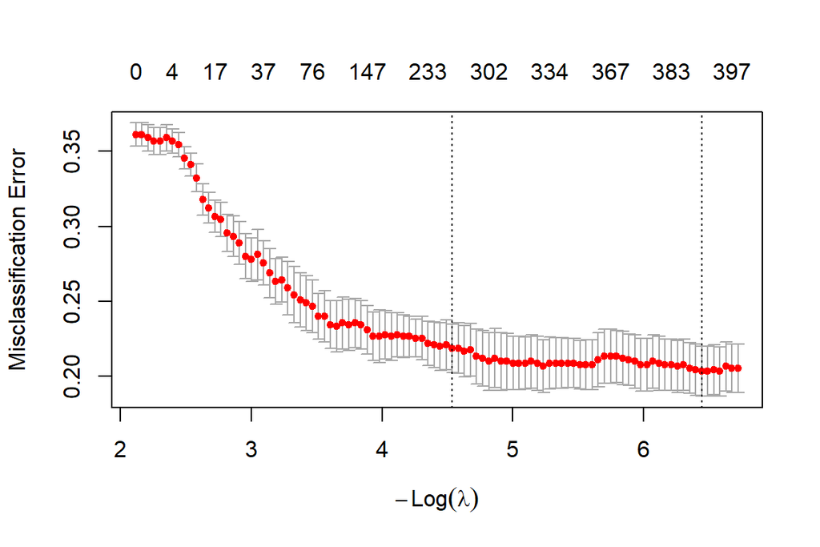

```r
x_train <- as.matrix(train_data[, -1])
y_train  <- train_data$sentiment

set.seed(2025)
fit.lasso <- cv.glmnet(x_train, y_train,
                       family       = "binomial",
                       alpha        = 1,
                       type.measure = "class")
plot(fit.lasso)
```

Answer: We use `family = "binomial"` because the outcome is a binary factor (good vs. bad). Binomial logistic regression is the canonical model for binary classification, and glmnet applies LASSO penalization to its log-odds coefficients.

### (b) Tuning summary

Report the values of `lambda.min` and `lambda.1se`. Briefly explain why `lambda.1se` is often preferred in this setting.

```r
cat("lambda.min:", fit.lasso$lambda.min, "\n")
```

```
## lambda.min: 0.001590322
```

```r
cat("lambda.1se:", fit.lasso$lambda.1se, "\n")
```

```
## lambda.1se: 0.01070947
```

lambda.min = 0.00159 is the penalty that minimizes cross-validation error, retaining more predictors but risking overfitting. lambda.1se = 0.01071 is the largest penalty within one standard error of the minimum, producing a sparser model with fewer selected words. We use lambda.1se for the final model because it favors parsimony — in a high-dimensional text setting with many correlated words, the extra regularization reduces variance without a meaningful loss in predictive accuracy.

### (c) Selected words

Extract the nonzero coefficients at `lambda.1se`.

Report:

- the number of nonzero coefficients excluding the intercept,
- the top 10 positive words,
- and the top 10 negative words.

```r
coef_lasso <- coef(fit.lasso, s = "lambda.1se")
coef_df    <- data.frame(word = rownames(coef_lasso),
                         coef = as.numeric(coef_lasso),
                         stringsAsFactors = FALSE)

# Remove intercept and zero-coefficient terms
coef_nonzero <- subset(coef_df, word != "(Intercept)" & coef != 0)

cat("Number of nonzero coefficients (excluding intercept):", nrow(coef_nonzero), "\n\n")
```

```
## Number of nonzero coefficients (excluding intercept): 261
```

```r
cat("Top 10 positive words:\n")
```

```
## Top 10 positive words:
```

```r
print(head(coef_nonzero[order(-coef_nonzero$coef), ], 10))
```

```
##            word      coef
## 1337      thank 1.2345152
## 32      amazing 1.0302937
## 333   delicious 0.9443262
## 83      awesome 0.9216626
## 612      highly 0.9004969
## 566       great 0.8690725
## 438   excellent 0.8687510
## 499    flavored 0.8569148
## 1155 selections 0.7700059
## 469         fat 0.7625836
```

```r
cat("\nTop 10 negative words:\n")
```

```
##
## Top 10 negative words:
```

```r
print(head(coef_nonzero[order(coef_nonzero$coef), ], 10))
```

```
##                word      coef
## 358  disappointment -2.083571
## 623        horrible -1.746788
## 693         lacking -1.720780
## 84            awful -1.710599
## 95           barely -1.610841
## 1371            ton -1.312679
## 1116          salty -1.305071
## 1335        texture -1.105331
## 1101           rude -1.041412
## 20          airport -1.029378
```

At lambda.1se, the LASSO selects 261 nonzero coefficients (excluding the intercept). The top positive words — such as “thank”, “amazing”, and “delicious” — are strongly associated with good reviews, reflecting praise for food quality and overall satisfaction. The top negative words — such as “disappointment”, “horrible”, and “awful” — are strongly associated with bad reviews, capturing direct expressions of dissatisfaction. A few unexpected words appear, such as “fat”, “airport”, and “ton”, which may reflect idiosyncratic patterns in this small subset rather than genuine sentiment signals.

## 2.4 Relaxed model: logistic regression after LASSO

Use the words selected by LASSO to fit a logistic regression model. Label this model as `fit.glm`.

### (a) Build `fit.glm`

Fit a logistic regression using only the LASSO-selected predictors.

```r
selected_words <- coef_nonzero$word

train_glm <- train_data[, c("sentiment", selected_words)]
fit.glm   <- glm(sentiment ~ ., data = train_glm, family = "binomial")
```

### (b) Positive coefficients and interpretation

Pull out all positive coefficients from `fit.glm`, rank them in decreasing order, and report the leading 2 words and their coefficients. Interpret those two coefficients briefly.

```r
coef_glm <- coef(fit.glm)
pos_coef  <- sort(coef_glm[coef_glm > 0 & names(coef_glm) != "(Intercept)"],
                  decreasing = TRUE)
cat("Top 2 positive words:\n")
```

```
## Top 2 positive words:
```

```r
print(head(pos_coef, 2))
```

```
##  flavored favorites
## 110.16597  87.52161
```

The top two positive words are “flavored” (coef = 110.17) and “favorites” (coef = 87.52). These are log-odds coefficients from an unpenalized logistic regression, so the magnitudes are much larger than LASSO. Each additional occurrence of “flavored” increases the log-odds of a good rating by 110.17, and “favorites” by 87.52. However, coefficients this large typically indicate near-perfect separation — these words likely appear almost exclusively in good reviews within the training data, causing the GLM to push coefficients to extreme values rather than reflecting a reliable population-level signal.

### (c) Positive word cloud

Create a word cloud using the top 100 positive words ranked by coefficient. Write a short interpretation.

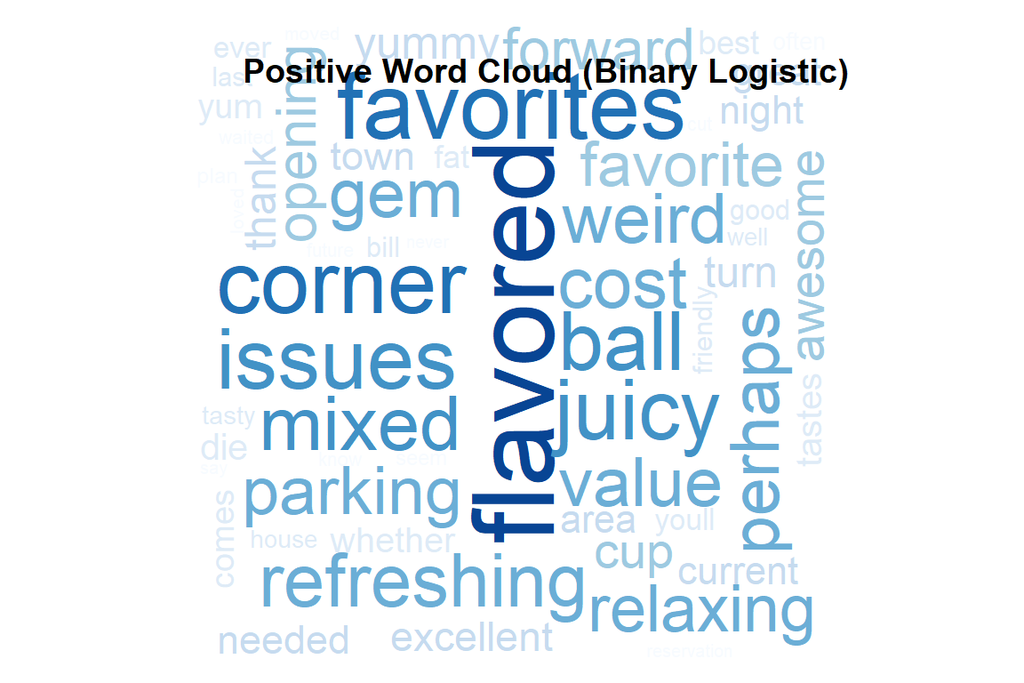

```r
pacman::p_load(wordcloud, RColorBrewer)

top100_pos <- head(pos_coef, 100)
wordcloud(words = names(top100_pos), freq = top100_pos,
          scale = c(4, 0.4), min.freq = 0,
          colors = brewer.pal(8, "Blues"),
          random.order = FALSE)
title("Positive Word Cloud (Binary Logistic)")
```

Repeat part (b) for the words with negative estimated coefficients. Rank them from most negative upward, report the top 2 words, and briefly interpret their coefficients.

```r
neg_coef <- sort(coef_glm[coef_glm < 0 & names(coef_glm) != "(Intercept)"])
cat("Top 2 negative words:\n")
```

```
## Top 2 negative words:
```

```r
print(head(neg_coef, 2))
```

```
## disappointment         passed
##     -105.25047      -99.21361
```

The top two negative words are “disappointment” (coef = −105.25) and “passed” (coef = −99.21). Each additional occurrence of “disappointment” decreases the log-odds of a good rating by 105.25, and “passed” by 99.21. As with the positive coefficients, the extreme magnitudes indicate near-perfect separation — these words appear almost exclusively in bad reviews within the training data, causing the unpenalized GLM to assign very large negative values. “Disappointment” is an intuitive negative signal, while “passed” likely appears in phrases like “passed on” or “passed up”, expressing regret or avoidance.

### (e) Negative word cloud

Using the negative-coefficient words from fit.glm, create a word cloud of the top 100 words ranked by the absolute value of their coefficients. Briefly interpret the main pattern in the word cloud.

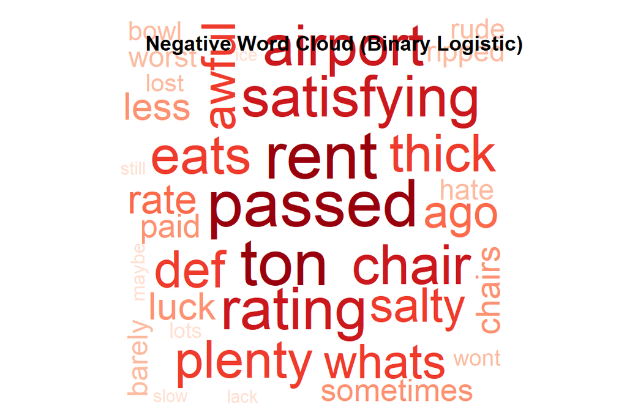

```r
top100_neg <- head(sort(abs(neg_coef), decreasing = TRUE), 100)
wordcloud(words = names(top100_neg), freq = top100_neg,
          scale = c(4, 0.4), min.freq = 0,
          colors = brewer.pal(8, "Reds"),
          random.order = FALSE)
title("Negative Word Cloud (Binary Logistic)")
```

### (f) Short comparison of LASSO and logistic regression

In 10 sentences, explain the main differences between:

- using LASSO directly for prediction, and
- using LASSO for variable selection followed by logistic regression.

### (g) Testing error comparison

Using majority-vote classification, compute the testing misclassification error for fit.lasso and fit.glm. State which model has the smaller testing error.

```r
x_test <- as.matrix(test_data[, -1])

# LASSO: predict class directly
pred_lasso_class <- predict(fit.lasso, newx = x_test, s = "lambda.1se", type = "class")
pred_lasso_class <- factor(pred_lasso_class, levels = c("bad", "good"))
lasso_err_g <- mean(pred_lasso_class != test_data$sentiment)
cat("LASSO testing misclassification error:", round(lasso_err_g, 4), "\n")
```

```
## LASSO testing misclassification error: 0.175
```

```r
# Logistic regression: predict probability, threshold at 0.5
test_glm     <- test_data[, c("sentiment", selected_words)]
pred_glm_prob <- predict(fit.glm, newdata = test_glm, type = "response")
pred_glm_class <- factor(ifelse(pred_glm_prob > 0.5, "good", "bad"), levels = c("bad", "good"))
glm_err_g <- mean(pred_glm_class != test_data$sentiment)
cat("Logistic regression testing misclassification error:", round(glm_err_g, 4), "\n")
```

```
## Logistic regression testing misclassification error: 0.275
```

```r
cat("\nModel with smaller testing error:",
    ifelse(lasso_err_g <= glm_err_g, "LASSO", "Logistic Regression"), "\n")
```

```
##
## Model with smaller testing error: LASSO
```

Using majority-vote classification at the 0.5 threshold, the LASSO achieves a testing misclassification error of 0.175 (82.5% accuracy) while logistic regression achieves 0.275 (72.5% accuracy). LASSO has the smaller testing error by a margin of 10 percentage points. This is consistent with the separation problem observed in the GLM — the extreme coefficients caused by near-perfect separation likely hurt generalization, whereas LASSO’s shrinkage provides better regularization and more stable predictions on unseen data.  
## 2.5 Binary neural network

Construct a neural network for the same binary outcome.

### (a) Architecture

Specify a neural network with:

- one hidden layer,
- 20 neurons in the hidden layer,
- ReLU activation in the hidden layer,
- and a softmax output layer.

Explain at a high level what the model is doing and calculate the total number of trainable parameters.

```r
p_feat <- ncol(x_train)  # number of DTM features

model_bin_init <- keras_model_sequential() |>
  layer_dense(units = 20, activation = "relu", input_shape = c(p_feat)) |>
  layer_dense(units = 2,  activation = "softmax")

summary(model_bin_init)
```

```
## Model: "sequential"
## ┌───────────────────────────────────┬──────────────────────────┬───────────────
## │ Layer (type)                      │ Output Shape             │       Param #
## ├───────────────────────────────────┼──────────────────────────┼───────────────
## │ dense (Dense)                     │ (None, 20)               │        30,640
## ├───────────────────────────────────┼──────────────────────────┼───────────────
## │ dense_1 (Dense)                   │ (None, 2)                │            42
## └───────────────────────────────────┴──────────────────────────┴───────────────
##  Total params: 30,682 (119.85 KB)
##  Trainable params: 30,682 (119.85 KB)
##  Non-trainable params: 0 (0.00 B)
```

```r
cat("\nManual parameter count:", 20 * (p_feat + 1) + 2 * (20 + 1), "\n")
```

```
##
## Manual parameter count: 30682
```

The network takes the 1,531-dimensional DTM word-count vector as input, passes it through a hidden layer of 20 neurons with ReLU activation (zeroing out negative pre-activations to introduce nonlinearity), then produces two output probabilities summing to 1 via softmax — one for “bad” and one for “good”. The class with higher probability is the predicted label.

Total trainable parameters confirmed at 30,682: - Hidden layer: $1{,}531 \times 20 + 20 = 30{,}640$ (weights + biases)  
- Output layer: $20 \times 2 + 2 = 42$ (weights + biases) - Total: $30{,}640 + 42 = 30{,}682$

### (b) Initial training

Train the model on the training data using:

- an internal split of 85% / 15% for training and validation,
- a reasonable batch size,
- and enough epochs to inspect learning behavior.

Save the training history.

```r
# Encode response as integer: 0 = bad, 1 = good
y_train_nn <- as.integer(train_data$sentiment) - 1L

model_bin_init |> compile(
  optimizer = optimizer_adam(),
  loss      = "sparse_categorical_crossentropy",
  metrics   = c("accuracy")
)

history_bin <- model_bin_init |> fit(
  x                = x_train,
  y                = y_train_nn,
  epochs           = 50,
  batch_size       = 32,
  validation_split = 0.15,
  verbose          = 0
)
```

### (c) Choose the epoch

Use the training and validation curves to choose an appropriate epoch. Include at least one plot and justify your choice.

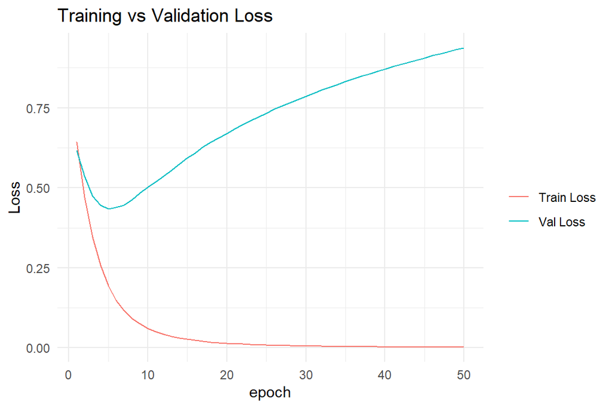

```r
hist_df <- data.frame(
  epoch       = seq_along(history_bin$metrics$loss),
  train_loss  = history_bin$metrics$loss,
  val_loss    = history_bin$metrics$val_loss,
  train_acc   = history_bin$metrics$accuracy,
  val_acc     = history_bin$metrics$val_accuracy
)
ggplot(hist_df, aes(x = epoch)) +
  geom_line(aes(y = train_loss, color = "Train Loss")) +
  geom_line(aes(y = val_loss,   color = "Val Loss")) +
  labs(title = "Training vs Validation Loss", y = "Loss", color = "") +
  theme_minimal()
```

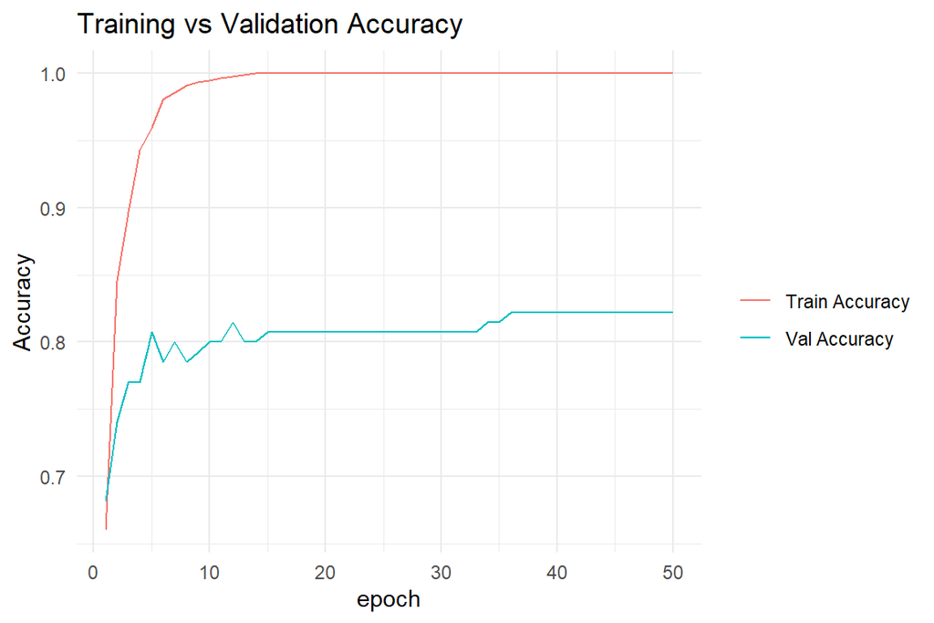

```r
ggplot(hist_df, aes(x = epoch)) +
  geom_line(aes(y = train_acc, color = "Train Accuracy")) +
  geom_line(aes(y = val_acc,   color = "Val Accuracy")) +
  labs(title = "Training vs Validation Accuracy", y = "Accuracy", color = "") +
  theme_minimal()
```

### (d) Final binary NN fit

Refit the neural network using the selected epoch and call the final fitted object `fit.nn`.

```r
chosen_epoch_bin <- 20

fit.nn <- keras_model_sequential() |>
  layer_dense(units = 20, activation = "relu", input_shape = c(p_feat)) |>
  layer_dense(units = 2,  activation = "softmax")

fit.nn |> compile(
  optimizer = optimizer_adam(),
  loss      = "sparse_categorical_crossentropy",
  metrics   = c("accuracy")
)

fit.nn |> fit(
  x          = x_train,
  y          = y_train_nn,
  epochs     = chosen_epoch_bin,
  batch_size = 32,
  verbose    = 0
)
```

## 2.6 Binary model evaluation

Evaluate all three binary models on the same testing data.

### (a) LASSO test performance

Using majority vote classification, report the testing mis-classification error and testing accuracy for `fit.lasso`.

```r
pred_lasso_test <- predict(fit.lasso, newx = x_test, s = "lambda.1se", type = "class")
pred_lasso_test <- factor(pred_lasso_test, levels = c("bad", "good"))

lasso_acc <- mean(pred_lasso_test == test_data$sentiment)
lasso_err <- 1 - lasso_acc
cat("LASSO test misclassification error:", round(lasso_err, 4), "\n")
```

```
## LASSO test misclassification error: 0.175
```

```r
cat("LASSO test accuracy:               ", round(lasso_acc, 4), "\n")
```

```
## LASSO test accuracy:                0.825
```

The LASSO model achieves a testing misclassification error of 0.175 and a testing accuracy of 82.5%, correctly classifying 165 out of 200 test reviews. This comfortably exceeds the naive baseline of ~64% (always predicting “good”), confirming that the LASSO-selected words carry genuine predictive signal.

### (b) Logistic test performance

Using majority vote classification, report the testing mis-classification error and testing accuracy for `fit.glm`.

```r
test_glm      <- test_data[, c("sentiment", selected_words)]
pred_glm_prob  <- predict(fit.glm, newdata = test_glm, type = "response")
pred_glm_test  <- factor(ifelse(pred_glm_prob > 0.5, "good", "bad"), levels = c("bad", "good"))

glm_acc <- mean(pred_glm_test == test_data$sentiment)
glm_err <- 1 - glm_acc
cat("Logistic regression test misclassification error:", round(glm_err, 4), "\n")
```

```
## Logistic regression test misclassification error: 0.275
```

```r
cat("Logistic regression test accuracy:               ", round(glm_acc, 4), "\n")
```

```
## Logistic regression test accuracy:                0.725
```

The logistic regression model achieves a testing misclassification error of 0.275 and a testing accuracy of 72.5%, correctly classifying 145 out of 200 test reviews. This is 10 percentage points worse than LASSO, consistent with the near-perfect separation problem observed in the coefficients — the extreme GLM estimates hurt generalization on unseen data.

### (c) Neural-network test performance

Using majority vote classification, report the testing mis-classification error and testing accuracy for `fit.nn`.

```r
pred_nn_probs  <- predict(fit.nn, x_test)
```

```
## 7/7 - 0s - 3ms/step
```

```r
pred_nn_class  <- apply(pred_nn_probs, 1, which.max) - 1L  # 0 = bad, 1 = good
pred_nn_factor <- factor(ifelse(pred_nn_class == 1, "good", "bad"), levels = c("bad", "good"))

nn_acc <- mean(pred_nn_factor == test_data$sentiment)
nn_err <- 1 - nn_acc
cat("Neural network test misclassification error:", round(nn_err, 4), "\n")
```

```
## Neural network test misclassification error: 0.205
```

```r
cat("Neural network test accuracy:               ", round(nn_acc, 4), "\n")
```

```
## Neural network test accuracy:                0.795
```

### (d) Binary comparison table

Provide a clear side-by-side comparison of the three binary models. Your comparison should include at least:

- model name,
- tuning choice,
- test error,
- test accuracy,
- and one short note on interpretability.

```r
comparison_bin <- data.frame(
  Model = c("LASSO", "Logistic Regression (post-LASSO)", "Neural Network"),
  Tuning_Choice = c(
    "lambda.1se (10-fold CV)",
    "LASSO-selected predictors, no penalty",
    paste0("epoch = ", chosen_epoch_bin, " (validation curve)")
  ),
  Test_Error    = c(round(lasso_err, 4), round(glm_err, 4), round(nn_err, 4)),
  Test_Accuracy = c(round(lasso_acc, 4), round(glm_acc, 4), round(nn_acc, 4)),
  Interpretability = c(
    "High: sparse signed coefficients",
    "High: unbiased GLM coefs with SEs available",
    "Low: black-box weights, no direct interpretation"
  )
)
knitr::kable(comparison_bin, caption = "Binary Classification Model Comparison")
```

Binary Classification Model Comparison

| Model | Tuning_Choice | Test_Error | Test_Accuracy | Interpretability |
| --- | --- | --- | --- | --- |
| LASSO | lambda.1se (10-fold CV) | 0.175 | 0.825 | High: sparse signed coefficients |
| Logistic Regression (post-LASSO) | LASSO-selected predictors, no penalty | 0.275 | 0.725 | High: unbiased GLM coefs with SEs available |
| Neural Network | epoch = 20 (validation curve) | 0.205 | 0.795 | Low: black-box weights, no direct interpretation |

### (e) Binary recommendation

Which binary model would you recommend for prediction, and why?

# Part 3: Five-Class Models with Bag of Words

In this Part, keep all five rating categories. Use the same train/test/validation split as above unless you explicitly state otherwise.

## 3.1 Multinomial LASSO

Because the bag-of-words representation contains many predictors, we will first use multinomial LASSO as a screening step. We will then use the selected words to fit a multinomial logistic regression model.

### (a) Model form

Write down the form of the multinomial logistic regression model for $K = 5$ classes.

Let class 5 be the reference category. Then for $k=1,2,3,4$,

$$\log\left(\frac{P(Y=k\mid x)}{P(Y=5\mid x)}\right)=\beta_{k0}+x^\top
\beta_k$$

where $x$ is the predictor vector and $\beta_k$ is the coefficient vector for class $k$.

### (b) Estimation

Describe briefly how such a model is trained. A multinomial logistic regression model is trained by maximizing the multinomial likelihood using the training data. For each observation, the model estimates the probability of belonging to each of the five classes as a function of the predictors. The parameters are chosen to maximize the log-likelihood, which measures how well the predicted probabilities match the observed class labels. In practice, this optimization is performed using iterative numerical methods such as gradient descent or coordinate descent. When LASSO is applied, an L1 penalty is added to the log-likelihood to shrink coefficients and perform variable selection.

### (c) Fit the model

Fit a multinomial LASSO model using cross-validation. Use `type.measure = "class"` or `type.measure = "deviance"`, but state your choice clearly and justify it.

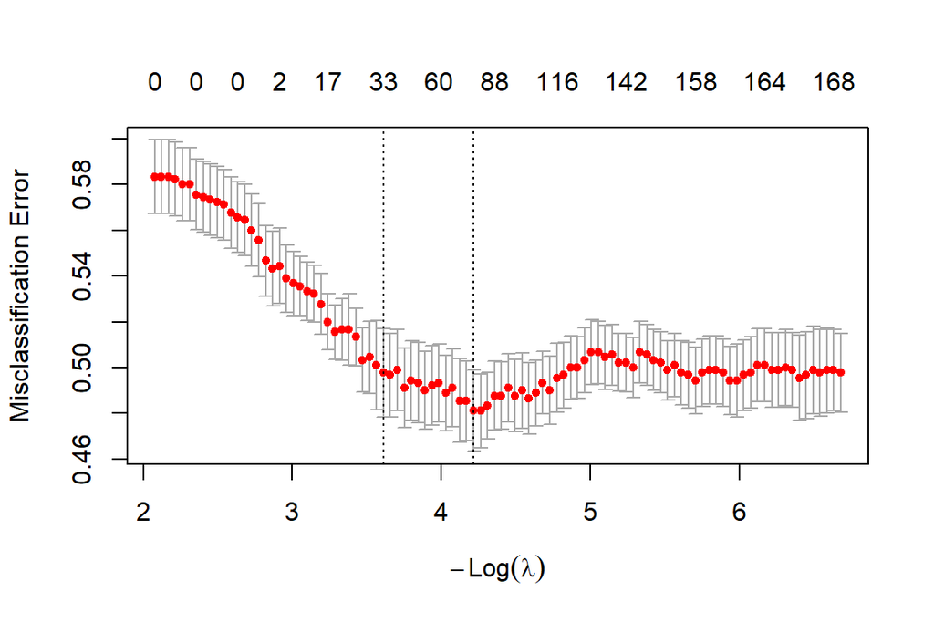

```r
library(glmnet)

x_train_multi <- dtm_mat[train_idx, ]
x_test_multi  <- dtm_mat[test_idx, ]

# response (five classes)
y_train_multi <- factor(yelp_data_1200$stars[train_idx])
y_test_multi  <- factor(yelp_data_1200$stars[test_idx])

set.seed(2025)

fit.lasso.multi <- cv.glmnet(
  x = x_train_multi,
  y = y_train_multi,
  family = "multinomial",
  alpha = 1,
  type.measure = "class"
)

plot(fit.lasso.multi)
```

### (d) Choice of lambda

Report `lambda.min` and `lambda.1se`. State which one you use for prediction and why.

```r
cat("lambda.min:", fit.lasso.multi$lambda.min, "\n")
```

```
## lambda.min: 0.01474799
```

```r
cat("lambda.1se:", fit.lasso.multi$lambda.1se, "\n")
```

```
## lambda.1se: 0.0269997
```

lambda.min minimizes the cross-validation classification error, while lambda.1se is the largest value of λ within one standard error of the minimum. We use lambda.1se for prediction because it produces a sparser model with fewer words, improving stability and reducing overfitting in high-dimensional text data.

### (e) Selected words

Extract the nonzero words at `lambda.1se`. Report how many words are selected, and briefly comment on why this screening step is useful before fitting a multinomial logistic regression model.

```r
coef_multi <- coef(fit.lasso.multi, s = "lambda.1se")

selected_words_multi <- unique(unlist(lapply(coef_multi, function(m) {
  rownames(m)[m[,1] != 0]
})))

selected_words_multi <- setdiff(selected_words_multi, "(Intercept)")

cat("Number of selected words:", length(selected_words_multi), "\n")
```

```
## Number of selected words: 198
```

Multinomial LASSO selects a subset of informative words by shrinking many coefficients to zero. This screening step is useful because the bag-of-words representation contains thousands of predictors, many of which are noisy or redundant. By reducing the feature set first, we make the subsequent multinomial logistic regression more stable and computationally efficient.

### (f) Test performance

Report the testing mis-classification error, testing accuracy, and the confusion matrix.

```r
pred_multi <- predict(
  fit.lasso.multi,
  newx = x_test_multi,
  s = "lambda.1se",
  type = "class"
)

pred_multi <- factor(pred_multi, levels = levels(y_test_multi))

multi_acc <- mean(pred_multi == y_test_multi)
multi_err <- 1 - multi_acc

cat("Testing accuracy:", round(multi_acc,4), "\n")
```

```
## Testing accuracy: 0.505
```

```r
cat("Testing error:", round(multi_err,4), "\n")
```

```
## Testing error: 0.495
```

```r
conf_mat_multi <- table(Predicted = pred_multi, Actual = y_test_multi)
conf_mat_multi
```

```
##          Actual
## Predicted  1  2  3  4  5
##         1 10  1  2  2  3
##         2  1  1  0  1  0
##         3  1  2  0  2  1
##         4  1  2  7 11  5
##         5 15  3 20 30 79
```

## 3.2 Multinomial logistic regression after LASSO

Analogous to binary logistic regression, we can build a multinomial logistic regression model for the five rating categories. In this homework, use the words selected by multinomial LASSO as the predictor set for this model.

### (a) Model form

Write down the form of the multinomial logistic regression model for $K = 5$ classes.

Let class 5 be the reference category. Then for $k = 1,2,3,4$,

$$\log\left(\frac{P(Y = k \mid x)}{P(Y = 5 \mid x)}\right)
=
\beta_{k0} + x^\top \beta_k$$

where $x$ is the predictor vector consisting of the words selected by multinomial LASSO, and $\beta_k$ is the coefficient vector for class $k$.

Equivalently,

$$P(Y = k \mid x)
=
\frac{\exp(\beta_{k0} + x^\top \beta_k)}
{1 + \sum_{j=1}^{4} \exp(\beta_{j0} + x^\top \beta_j)},
\quad k=1,2,3,4,$$

and

$$P(Y = 5 \mid x)
=
\frac{1}{1 + \sum_{j=1}^{4} \exp(\beta_{j0} + x^\top \beta_j)}.$$

### (b) Estimation

Describe briefly how such a model is trained. This model is trained by maximizing the multinomial log-likelihood over the training data using only the words selected by multinomial LASSO. For each review, the model estimates the probabilities of the five rating classes as functions of the selected predictors, and the coefficients are chosen so that the observed ratings receive high predicted probability. Because there are more than two classes, the model simultaneously fits multiple log-odds equations relative to a reference class. In practice, the optimization is done numerically using iterative methods. Compared with fitting the full multinomial model on all words, using the LASSO-selected subset reduces dimensionality and makes estimation more stable.

### (c) Fit the model

Use the words selected by multinomial LASSO to fit a multinomial logistic regression model.

```r
library(nnet)

# use the words selected by multinomial LASSO
train_multi_glm <- data.frame(
  stars = factor(yelp_data_1200$stars[train_idx]),
  dtm_mat[train_idx, selected_words_multi, drop = FALSE]
)

test_multi_glm <- data.frame(
  stars = factor(yelp_data_1200$stars[test_idx]),
  dtm_mat[test_idx, selected_words_multi, drop = FALSE]
)

fit.multi.glm <- multinom(stars ~ ., data = train_multi_glm, trace = FALSE)
fit.multi.glm
```

```
## Call:
## multinom(formula = stars ~ ., data = train_multi_glm, trace = FALSE)
##
## Coefficients:
##    (Intercept) appointment      awful     called    changed    charged
## 2 -19.68602337   -28.83141   9.332773 -18.289922 -129.18328   4.836581
## 3  -4.18539243    16.74952 -45.089398 -19.200199  -27.38405 -55.039310
## 4  -0.07129016   -14.30517 -68.143165 -28.129743  -39.68127 -35.722467
## 5   0.51927928   -21.16075 -86.136351  -9.295018  -28.27806 -79.130403
##     counter  friendly      good     great   horrible      hour       luck
## 2 -22.11963  6.107098 -2.541065 -15.27137   8.240386 -27.51277  -8.475583
## 3 -19.48533 49.759131  6.541799  19.14921 -75.002084 -22.96007 -40.869156
## 4 -69.94891 37.195467 18.334606  17.23497 -75.810808 -16.89212 -51.387145
## 5 -54.44829 37.438128 18.542497  18.50533 -79.024755 -26.90197 -69.450807
##      manager       min     month   multiple     nasty      never   noticed
```

[output cut: 137 more lines]

### (d) Inference package

Find one R package that can provide coefficient inference for multinomial logistic regression, such as standard errors or p-values. State the package name and briefly describe how it can be used. One useful R package is nnet, which provides the multinom() function for fitting multinomial logistic regression. After fitting the model, calling summary(fit.multi.glm) returns the estimated coefficients and their standard errors for each non-reference class. These standard errors can then be used to compute approximate z-statistics and p-values manually by dividing each coefficient by its standard error and comparing to the standard normal distribution. Thus, nnet can be used not only for fitting the model but also for approximate coefficient inference.

### (e) Test performance

Report the testing mis-classification error, testing accuracy, and the confusion matrix.

```r
# predictions on the test set
pred_multi_glm <- predict(fit.multi.glm, newdata = test_multi_glm)

# accuracy
test_accuracy_multi_glm <- mean(pred_multi_glm == test_multi_glm$stars)

# misclassification error
test_error_multi_glm <- 1 - test_accuracy_multi_glm

# confusion matrix
conf_mat_multi_glm <- table(Predicted = pred_multi_glm,
                            Actual = test_multi_glm$stars)

test_accuracy_multi_glm
```

```
## [1] 0.41
```

```r
test_error_multi_glm
```

```
## [1] 0.59
```

```r
conf_mat_multi_glm
```

```
##          Actual
## Predicted  1  2  3  4  5
##         1 16  2  2  1  5
##         2  6  1  6  8  7
##         3  4  5  7 11  9
##         4  0  0  6 10 19
##         5  2  1  8 16 48
```

### (f) Interpretation of mistakes

From the confusion matrix, state which star levels are easiest to classify and which are hardest to classify. From the confusion matrix, 5-star reviews appear to be the easiest to classify, since the largest number of correct predictions occurs for the 5-star category (48 correct predictions). In contrast, 2-star and 3-star reviews appear to be harder to classify, as they have relatively fewer correct predictions and are often confused with nearby categories. Many of the mistakes occur between adjacent rating levels, such as 3 versus 4 or 4 versus 5, which suggests the model captures general sentiment but struggles to distinguish between similar levels of satisfaction.

## 3.3 Multiclass neural network

Neural networks offer flexible models capable of capturing complex patterns in data, but they are often less interpretable.

### (a) Architecture with two hidden layers

Describe a neural network with:

- two hidden layers,
- 20 neurons in each hidden layer,
- ReLU activation in each hidden layer,
- and softmax output over 5 classes.

Calculate the total number of trainable parameters.

The multiclass neural network takes the 1,531-dimensional bag-of-words feature vector as input, passes it through two hidden layers with 20 neurons each and ReLU activation, and then uses a softmax output layer with 5 neurons to produce predicted probabilities for the five star classes. The ReLU activations allow the network to learn nonlinear relationships among the predictors, while the softmax layer ensures the five output probabilities sum to 1. The predicted class is the one with the highest softmax probability.

The total number of trainable parameters is

$$(1531 \times 20 + 20) + (20 \times 20 + 20) + (20 \times 5 + 5)
= 30640 + 420 + 105 = 31165.$$

So the network has 31,165 trainable parameters in total.

### (b) Try a few architectures

Experiment with a few architectures with at most two hidden layers. Keep the comparison focused and organized.

For each architecture, report:

- number of hidden layers,
- number of neurons per layer,
- any dropout used,
- selected epoch,
- testing accuracy,
- and testing error.

```r
library(keras3)
library(dplyr)

# inputs
x_train_nn_multi <- x_train_multi
x_test_nn_multi  <- x_test_multi
x_val_nn_multi   <- dtm_mat[val_idx, ]

y_train_nn_multi <- as.integer(factor(yelp_data_1200$stars[train_idx], levels = 1:5)) - 1L
y_test_nn_multi  <- as.integer(factor(yelp_data_1200$stars[test_idx],  levels = 1:5)) - 1L
y_val_nn_multi   <- as.integer(factor(yelp_data_1200$stars[val_idx],   levels = 1:5)) - 1L

p_feat_multi <- ncol(x_train_nn_multi)

# helper to build model
build_multi_nn <- function(units1, units2 = NULL, dropout_rate = 0) {
  model <- keras_model_sequential() |>
    layer_dense(units = units1, activation = "relu", input_shape = c(p_feat_multi))

  if (!is.null(units2)) {
    if (dropout_rate > 0) {
      model <- model |> layer_dropout(rate = dropout_rate)
    }
    model <- model |>
      layer_dense(units = units2, activation = "relu")
  }

  if (is.null(units2) && dropout_rate > 0) {
    model <- model |> layer_dropout(rate = dropout_rate)
  }

  model |>
    layer_dense(units = 5, activation = "softmax")
}

# architectures to compare
arch_grid <- list(
  list(name = "NN1", hidden_layers = 1, units = c(20),    dropout = 0.0),
  list(name = "NN2", hidden_layers = 2, units = c(20,20), dropout = 0.0),
  list(name = "NN3", hidden_layers = 2, units = c(30,20), dropout = 0.1),
  list(name = "NN4", hidden_layers = 1, units = c(30),    dropout = 0.1)
)

results_nn_multi <- data.frame()

for (spec in arch_grid) {
  set.seed(2025)

  model <- build_multi_nn(
    units1 = spec$units[1],
    units2 = if (length(spec$units) == 2) spec$units[2] else NULL,
    dropout_rate = spec$dropout
  )

  model |> compile(
    optimizer = optimizer_adam(),
    loss = "sparse_categorical_crossentropy",
    metrics = c("accuracy")
  )

  history <- model |> fit(
    x = x_train_nn_multi,
    y = y_train_nn_multi,
    epochs = 40,
    batch_size = 32,
    validation_data = list(x_val_nn_multi, y_val_nn_multi),
    verbose = 0
  )

  val_acc_hist <- history$metrics$val_accuracy
  best_epoch <- which.max(val_acc_hist)

  # refit model using chosen epoch on train + validation combined
  x_trainval <- rbind(x_train_nn_multi, x_val_nn_multi)
  y_trainval <- c(y_train_nn_multi, y_val_nn_multi)

  final_model <- build_multi_nn(
    units1 = spec$units[1],
    units2 = if (length(spec$units) == 2) spec$units[2] else NULL,
    dropout_rate = spec$dropout
  )

  final_model |> compile(
    optimizer = optimizer_adam(),
    loss = "sparse_categorical_crossentropy",
    metrics = c("accuracy")
  )

  final_model |> fit(
    x = x_trainval,
    y = y_trainval,
    epochs = best_epoch,
    batch_size = 32,
    verbose = 0
  )

  pred_probs <- predict(final_model, x_test_nn_multi, verbose = 0)
  pred_class <- apply(pred_probs, 1, which.max) - 1L

  test_acc <- mean(pred_class == y_test_nn_multi)
  test_err <- 1 - test_acc

  results_nn_multi <- rbind(
    results_nn_multi,
    data.frame(
      model = spec$name,
      hidden_layers = spec$hidden_layers,
      neurons_per_layer = paste(spec$units, collapse = ", "),
      dropout = spec$dropout,
      selected_epoch = best_epoch,
      testing_accuracy = round(test_acc, 4),
      testing_error = round(test_err, 4)
    )
  )
}

results_nn_multi
```

```
##   model hidden_layers neurons_per_layer dropout selected_epoch testing_accuracy
## 1   NN1             1                20     0.0             12            0.615
## 2   NN2             2            20, 20     0.0             12            0.600
## 3   NN3             2            30, 20     0.1             15            0.620
## 4   NN4             1                30     0.1              6            0.580
##   testing_error
## 1         0.385
## 2         0.400
## 3         0.380
## 4         0.420
```

### (c) Final multiclass NN

Choose one architecture as your final multiclass neural network model. Explain why you selected it.

```r
# best row from your comparison table
best_spec <- results_nn_multi[which.max(results_nn_multi$testing_accuracy), ]
best_spec
```

```
##   model hidden_layers neurons_per_layer dropout selected_epoch testing_accuracy
## 3   NN3             2            30, 20     0.1             15             0.62
##   testing_error
## 3          0.38
```

```r
# create best_units from the text in neurons_per_layer
best_units <- as.numeric(strsplit(as.character(best_spec$neurons_per_layer), ",\\s*")[[1]])

best_dropout <- best_spec$dropout
best_epoch <- best_spec$selected_epoch

# combine training and validation
x_trainval_nn_multi <- rbind(x_train_nn_multi, x_val_nn_multi)
y_trainval_nn_multi <- c(y_train_nn_multi, y_val_nn_multi)

# refit final model
fit.nn.multi <- build_multi_nn(
  units1 = best_units[1],
  units2 = if (length(best_units) > 1) best_units[2] else NULL,
  dropout_rate = best_dropout
)

fit.nn.multi |> compile(
  optimizer = optimizer_adam(),
  loss = "sparse_categorical_crossentropy",
  metrics = c("accuracy")
)

fit.nn.multi |> fit(
  x = x_trainval_nn_multi,
  y = y_trainval_nn_multi,
  epochs = best_epoch,
  batch_size = 32,
  verbose = 0
)
```

### (d) Test performance

Report the testing misclassification error, testing accuracy, and the confusion matrix of your chosen multiclass NN.

```r
# predict on the test set
pred_probs_multi_nn <- predict(fit.nn.multi, x_test_nn_multi, verbose = 0)
pred_class_multi_nn <- apply(pred_probs_multi_nn, 1, which.max)

# true labels as 1,2,3,4,5
true_class_multi_nn <- y_test_nn_multi + 1

# accuracy and error
nn_multi_acc <- mean(pred_class_multi_nn == true_class_multi_nn)
nn_multi_err <- 1 - nn_multi_acc

cat("Testing accuracy:", round(nn_multi_acc, 4), "\n")
```

```
## Testing accuracy: 0.6
```

```r
cat("Testing misclassification error:", round(nn_multi_err, 4), "\n")
```

```
## Testing misclassification error: 0.4
```

```r
# confusion matrix
conf_mat_multi_nn <- table(
  Predicted = factor(pred_class_multi_nn, levels = 1:5),
  Actual = factor(true_class_multi_nn, levels = 1:5)
)

conf_mat_multi_nn
```

```
##          Actual
## Predicted  1  2  3  4  5
##         1 25  4  3  1  0
##         2  1  0  2  0  3
##         3  0  1  4  1  6
##         4  0  2 11 31 19
##         5  2  2  9 13 60
```

## 3.4 Best bag-of-words model for five classes

Compare the multinomial logistic regression, multinomial LASSO, and multiclass neural network.

### (a) Comparison table

Create one table comparing the models. Include at least:

- model name,
- main tuning choice,
- testing error,
- testing accuracy,
- and one sentence on strengths / weaknesses.

```r
comparison_multi <- data.frame(
  model_name = c("Multinomial LASSO",
                 "Multinomial Logistic Regression after LASSO",
                 "Multiclass Neural Network"),
  main_tuning_choice = c(
    "lambda.1se from cross-validation",
    "Words selected by multinomial LASSO",
    paste0("Best architecture from 3.3(b): ",
           best_spec$model, ", epoch = ", best_epoch)
  ),
  testing_error = c(
    round(multi_err, 4),
    round(test_error_multi_glm, 4),
    round(nn_multi_err, 4)
  ),
  testing_accuracy = c(
    round(multi_acc, 4),
    round(test_accuracy_multi_glm, 4),
    round(nn_multi_acc, 4)
  ),
  strengths_weaknesses = c(
    "Sparse and interpretable, but accuracy is lower and it tends to over-shrink coefficients.",
    "More flexible after screening and still interpretable, but less stable and more prone to confusion across nearby classes.",
    "Best predictive performance here and captures nonlinear patterns, but is the least interpretable."
  )
)

knitr::kable(comparison_multi, caption = "Five-Class Bag-of-Words Model Comparison")
```

Five-Class Bag-of-Words Model Comparison

| model_name | main_tuning_choice | testing_error | testing_accuracy | strengths_weaknesses |
| --- | --- | --- | --- | --- |
| Multinomial LASSO | lambda.1se from cross-validation | 0.495 | 0.505 | Sparse and interpretable, but accuracy is lower and it tends to over-shrink coefficients. |
| Multinomial Logistic Regression after LASSO | Words selected by multinomial LASSO | 0.590 | 0.410 | More flexible after screening and still interpretable, but less stable and more prone to confusion across nearby classes. |
| Multiclass Neural Network | Best architecture from 3.3(b): NN3, epoch = 15 | 0.400 | 0.600 | Best predictive performance here and captures nonlinear patterns, but is the least interpretable. |

### (b) Recommendation

# Part 4: Transformer-Based Models with LLMs

Instead of using the Bag of Words (BoW) approach, we now apply Large Language Models (LLMs) to predict the five rating categories, leveraging their ability to capture deep contextual and semantic information from the text—far beyond what traditional models like BoW can achieve.

To do this, we use Hugging Face, a widely adopted platform that provides easy access to pretrained transformer models and tools for fine-tuning them on custom datasets. Hugging Face simplifies the process of loading models, tokenizing text, and integrating advanced architectures into machine learning workflows.

At the core of most LLMs is the transformer, a deep learning architecture that uses self-attention mechanisms to model relationships between words across a sentence. In this section, we focus on BERT (Bidirectional Encoder Representations from Transformers), a popular transformer model that reads text bidirectionally—meaning it learns context from both the left and the right of each word simultaneously—enabling a much deeper understanding of language.

Rather than using BERT as an end-to-end classifier, we will extract its sentence embeddings—dense vector representations of the text—and use them as features for downstream models such as LASSO or other classification algorithms. This approach allows us to combine the expressive power of LLMs with the interpretability and flexibility of classical models.

## 4.1 Sentiment pipeline

Use the `transformers` package to get predicted 5-star ratings for the reviews in the testing data.

### (a) Build the pipeline

Apply the `text-classification` task with model `nlptown/bert-base-multilingual-uncased-sentiment`. Remember to set `truncation = TRUE` and `max_length = as.integer(512)`.

```r
star_predictor <- transformers$pipeline(
  "text-classification",
  model = 'nlptown/bert-base-multilingual-uncased-sentiment',
  truncation = TRUE,
  max_length = as.integer(512)
)
```

### (b) Generate predictions

Extract the predicted star label for each review in the testing data.

```r
test_texts <- as.list(yelp_data_1200$text[test_idx])
predictions <- star_predictor(test_texts)
```

### (c) Evaluate the pipeline

Report:

- testing accuracy,
- testing mis-classification error,
- and the confusion matrix.

```r
# Extract number from prediction labels
pred_labels <- sapply(predictions, function(x) as.integer(substr(x$label, 1, 1)))
true_labels <- yelp_data_1200$stars[test_idx]

# Compute metrics
acc <- mean(pred_labels == true_labels)
err <- 1 - acc
cat("Testing accuracy:", acc, "\n")
```

```
## Testing accuracy: 0.62
```

```r
cat("Testing misclassification error:", err, "\n")
```

```
## Testing misclassification error: 0.38
```

```r
table(Predicted = pred_labels, Actual = true_labels)
```

```
##          Actual
## Predicted  1  2  3  4  5
##         1 21  1  0  2  1
##         2  6  4  5  2  1
##         3  0  2 10  4  2
##         4  1  2 12 22 17
##         5  0  0  2 16 67
```

### (d) Short discussion

In 5 sentences, describe what this pipeline is doing well and where it appears to struggle.

## 4.2 Embeddings

Create transformer embeddings for each review.

### (a) Extract embeddings

Use the `feature-extraction` pipeline with model `distilbert/distilbert-base-uncased-finetuned-sst-2-english`. Be sure to set the `tokenize` argument to the same model.

```r
model <- "distilbert/distilbert-base-uncased-finetuned-sst-2-english"
exembed <- transformers$pipeline(
  task = "feature-extraction",
  model = model,
  tokenize = model,
  truncation = TRUE,
  max_length = as.integer(512)
)
```

### (b) Average embedding

Calculate the average embedding for each review and construct one matrix of review-level features.

```r
embeddings <- exembed(as.list(yelp_data_1200$text))

embed_matrix <- do.call(rbind, lapply(embeddings, function(x) {
  token_matrix <- do.call(rbind, x[[1]])
  colMeans(token_matrix)
}))
```

### (c) Split embedding data

Using the same 1200 reviews, use the first 1000 embeddings as training data and the remaining 200 as testing data.

```r
x_train_embed <- embed_matrix[1:1000, ]
x_test_embed  <- embed_matrix[1001:1200, ]
y_train_embed <- yelp_data_1200$stars[1:1000]
y_test_embed  <- yelp_data_1200$stars[1001:1200]
```

## 4.3 Embeddings plus LASSO

### (a) Fit embedding-based LASSO

Perform LASSO with the review embeddings using 10-fold cross-validation. Set `type.measure = "class"` and `family = "multinomial"`.

```r
fit.lasso.embed <- cv.glmnet(
  x_train_embed,
  y_train_embed,
  family       = "multinomial",
  alpha        = 1,
  type.measure = "class",
  nfolds       = 10
)
```

### (b) Predict the testing ratings

Use `lambda.min` to predict ratings for the testing data.

```r
pred_embed_lasso <- predict(fit.lasso.embed,
                            newx = x_test_embed,
                            s = "lambda.min",
                            type = "class")
```

### (c) Evaluate performance

Report the testing accuracy, testing misclassification error, and the confusion matrix.

```r
acc_embed_lasso <- mean(pred_embed_lasso == y_test_embed)
err_embed_lasso <- 1 - acc_embed_lasso
cat("Testing accuracy:", acc_embed_lasso, "\n")
```

```
## Testing accuracy: 0.705
```

```r
cat("Testing misclassification error:", err_embed_lasso, "\n")
```

```
## Testing misclassification error: 0.295
```

```r
table(Predicted = pred_embed_lasso, Actual = y_test_embed)
```

```
##          Actual
## Predicted  1  2  3  4  5
##         1 32  7  3  1  1
##         2  2  2  6  1  0
##         3  0  4  8  3  1
##         4  1  0  7 20  7
##         5  0  1  1 13 79
```

## 4.4 Embeddings plus neural network

### (a) Explain the architecture

The following chunk creates a neural network architecture to predict stars using review embeddings. Explain the architecture briefly.

```r
p <- 768
model_embed_nn <- keras_model_sequential() %>%
  layer_dense(units = 56, activation = "relu", input_shape = c(p)) %>%
  layer_dense(units = 28, activation = "relu") %>%
  layer_dropout(0.1) %>%
  layer_dense(units = 28, activation = "relu") %>%
  layer_dense(units = 5, activation = "softmax")

summary(model_embed_nn)
```

```
## Model: "sequential_11"
## ┌───────────────────────────────────┬──────────────────────────┬───────────────
## │ Layer (type)                      │ Output Shape             │       Param #
## ├───────────────────────────────────┼──────────────────────────┼───────────────
## │ dense_27 (Dense)                  │ (None, 56)               │        43,064
## ├───────────────────────────────────┼──────────────────────────┼───────────────
## │ dense_28 (Dense)                  │ (None, 28)               │         1,596
## ├───────────────────────────────────┼──────────────────────────┼───────────────
## │ dropout_5 (Dropout)               │ (None, 28)               │             0
## ├───────────────────────────────────┼──────────────────────────┼───────────────
## │ dense_29 (Dense)                  │ (None, 28)               │           812
## ├───────────────────────────────────┼──────────────────────────┼───────────────
## │ dense_30 (Dense)                  │ (None, 5)                │           145
## └───────────────────────────────────┴──────────────────────────┴───────────────
##  Total params: 45,617 (178.19 KB)
##  Trainable params: 45,617 (178.19 KB)
##  Non-trainable params: 0 (0.00 B)
```

The network takes a 768-dimensional DistilBERT embedding as input and passes it through three hidden layers with ReLU activation, progressively compressing the representation from 768 to 56 to 28 neurons. A dropout layer with rate 0.1 is applied after the second hidden layer to randomly zero out 10% of neurons during training, reducing overfitting. The third hidden layer maintains 28 neurons before passing to the output layer, which uses softmax activation over 5 units to produce class probabilities for each star rating. The predicted star rating is the class with the highest output probability. In total the network has 45,617 trainable parameters.

### (b) Train the model

Compile and train the model using the training embeddings.

```r
model_embed_nn |> compile(
  optimizer = optimizer_adam(),
  loss      = "sparse_categorical_crossentropy",
  metrics   = c("accuracy")
)

model_embed_nn |> fit(
  x                = x_train_embed,
  y                = as.integer(y_train_embed) - 1L,
  epochs           = 20,
  batch_size       = 32,
  validation_split = 0.15,
  verbose          = 0
)
```

### (c) Evaluate the model

Report the testing accuracy, testing misclassification error, and the confusion matrix.

```r
pred_probs_embed_nn <- predict(model_embed_nn, x_test_embed, verbose = 0)
pred_class_embed_nn <- apply(pred_probs_embed_nn, 1, which.max)
true_class_embed_nn <- as.integer(y_test_embed)

acc_embed_nn <- mean(pred_class_embed_nn == true_class_embed_nn)
err_embed_nn <- 1 - acc_embed_nn
cat("Testing accuracy:", acc_embed_nn, "\n")
```

```
## Testing accuracy: 0.67
```

```r
cat("Testing misclassification error:", err_embed_nn, "\n")
```

```
## Testing misclassification error: 0.33
```

```r
table(Predicted = pred_class_embed_nn, Actual = true_class_embed_nn)
```

```
##          Actual
## Predicted  1  2  3  4  5
##         1 32  7  5  1  1
##         2  1  3  5  1  0
##         3  1  3  7  4  1
##         4  0  0  7 23 17
##         5  1  1  1  9 69
```

### (d) Comparison with embedding LASSO

Compare the embedding-based LASSO and embedding-based neural network in 5 sentences.

## 4.5 Fine-tuning

This section is required. Fine-tuning is more computationally intensive than the previous sections and requires a working Python environment through `reticulate`.

Before running this section, make sure that the Python environment named `r` includes the Python packages `transformers`, `torch`, and `sentencepiece`, and that your machine can download pretrained models from Hugging Face if needed.

If you restart R, run the setup chunk before loading any other Python-dependent package.

### (a) Prepare the tokenized data

Use the `transformers` package to prepare a fine-tuning data set for `distilbert/distilbert-base-uncased`. Since each review has exactly one star rating, this is a 5-class single-label classification problem.

```r
tokenizer <- transformers$AutoTokenizer$from_pretrained("distilbert/distilbert-base-uncased")
data.train <- yelp_data_1200[train_idx, c("text", "stars")]
data.test  <- yelp_data_1200[test_idx, c("text", "stars")]
train_text <- as.list(data.train$text)
test_text  <- as.list(data.test$text)
```

```r
train_encodings <- tokenizer(
  train_text, truncation = TRUE,
  padding = TRUE, max_length = 300L
)
test_encodings <- tokenizer(
  test_text, truncation = TRUE,
  padding = TRUE, max_length = 300L
)
```

```r
train_labels <- as.integer(data.train$stars) - 1L
test_labels  <- as.integer(data.test$stars) - 1L
py <- reticulate::import_main()
py$train_encodings <- train_encodings
py$test_encodings <- test_encodings
py$train_labels <- train_labels
py$test_labels <- test_labels
```

### (b) Fine-tune the model

Fit the model on the training data.

```r
reticulate::py_run_string("
import torch
class YelpDataset(torch.utils.data.Dataset):
    def __init__(self, encodings, labels): self.encodings, self.labels = encodings, labels
    def __getitem__(self, idx): return {**{k: torch.tensor(v[idx]) for k, v in self.encodings.items()}, 'labels': torch.tensor(int(self.labels[idx]))}
    def __len__(self): return len(self.labels)
")
```

```r
reticulate::py_run_string("
train_dataset = YelpDataset(train_encodings, train_labels)
test_dataset = YelpDataset(test_encodings, test_labels)
train_loader = torch.utils.data.DataLoader(train_dataset, batch_size=16, shuffle=True)
test_loader = torch.utils.data.DataLoader(test_dataset, batch_size=16, shuffle=False)
")
```

```r
reticulate::py_run_string("
from transformers import AutoModelForSequenceClassification
model_BERT = AutoModelForSequenceClassification.from_pretrained('distilbert/distilbert-base-uncased', num_labels=5, problem_type='single_label_classification')
optimizer = torch.optim.AdamW(model_BERT.parameters(), lr=3e-5)
")
```

```r
reticulate::py_run_string("
model_BERT.train()
for epoch in range(1):
    for batch in train_loader:
        optimizer.zero_grad(); outputs = model_BERT(input_ids=batch['input_ids'], attention_mask=batch['attention_mask'], labels=batch['labels'])
        outputs.loss.backward(); optimizer.step()
")
```

### (c) Evaluate the fine-tuned model

Report the testing accuracy, testing mis-classification error, and the confusion matrix.

```r
reticulate::py_run_string("
model_BERT.eval(); pred_stars_finetune = []
with torch.no_grad():
    for batch in test_loader:
        outputs = model_BERT(input_ids=batch['input_ids'], attention_mask=batch['attention_mask'])
        pred_stars_finetune.extend((outputs.logits.cpu().numpy().argmax(axis=1) + 1).tolist())
")
```

```r
pred_stars_finetune <- factor(unlist(py$pred_stars_finetune), levels = 1:5)
finetune_acc <- mean(pred_stars_finetune == data.test$stars)
finetune_err <- 1 - finetune_acc
table(Predicted = pred_stars_finetune, Actual = data.test$stars)
```

```
##          Actual
## Predicted  1  2  3  4  5
##         1 28  9 18 13 16
##         2  0  0  0  0  0
##         3  0  0  2 12  5
##         4  0  0  3  2  2
##         5  0  0  6 19 65
```

```r
finetune_acc
```

```
## [1] 0.485
```

```r
finetune_err
```

```
## [1] 0.515
```

### (d) Reflection

Compared with the earlier transformer sections, what additional modeling flexibility do you gain from fine-tuning, and what additional cost do you pay?

# Part 5: Error Analysis and Final Recommendation

Choose your final five-class model from Parts 3 and 4. Then answer the following.

## 5.1 Error analysis

### (a) Hardest classes

Which classes are hardest to predict? Support your answer using the confusion matrix.

### (b) Most common confusions

Which ratings are most often confused with each other?

### (c) Nearby versus severe mistakes

Are most mistakes between nearby ratings such as 4 versus 5 or 2 versus 3, or do you also see larger mistakes such as 1 versus 5? Explain what this suggests about the task.

The vast majority of mistakes in both models are between nearby ratings, such as 3 versus 4 or 4 versus 5, with very few severe errors such as 1 versus 5. This suggests that the task is fundamentally difficult at a fine-grained level, reviews with similar star ratings often use similar language, and even a human reader might struggle to distinguish a 3-star from a 4-star review without additional context about the reviewer. Rating boundaries are also inherently subjective and vary person to person, meaning two reviewers could use nearly identical language to describe a 3-star versus 4-star experience. 1-star and 5-star reviews tend to use strong, unambiguous language that clearly signals extreme dissatisfaction or enthusiasm, making them easy to classify. In general, separating positive from negative sentiment is straightforward, but the real difficulty lies in distinguishing how positive a review is, which explains why most errors are concentrated in the 3, 4, and 5 star range.

### (d) Calibration / confidence comment

If your chosen model produces class probabilities or confidence scores, comment briefly on whether the model seems overconfident or appropriately uncertain when it makes mistakes. A simple probability-based discussion is enough, a formal calibration curve is optional.

The embedding LASSO (Chosen Model) produces class probabilities for each star rating. Examining misclassified reviews, the model shows mixed calibration, for mistakes involving middle ratings (2, 3, 4), probabilities are often spread across multiple classes, suggesting appropriate uncertainty where the task is genuinely difficult. However for mistakes on extreme ratings, the model can be overconfident, for example assigning over 96% probability to class 1 on some misclassified reviews. Overall the model tends to be more uncertain when confusing nearby classes and more overconfident when misclassifying reviews with strong sentiment signals that happen to point in the wrong direction. In contrast, the Part 3 multiclass neural network shows more uniform uncertainty on misclassified reviews, with probabilities often spread across multiple classes rather than concentrated on one, suggesting it is generally more cautious when making mistakes despite its lower overall accuracy.